# 09. 다구치 실험계획

## 09.01. 직교배열표

- 일반적으로 실험에서 고려해야 할 요인들의 개수는 10 ~ 20개, 주효과와 상호작용효과를 고려하면 총 실험횟수는 기하급수적으로 증가
- 경험적으로 공업실험에서 잘 알려진 것은 **Factor Sparsity (유의한 요인의 수는 3, 4개이고 2요인 상호작용효과까지 포함하면 유의한 것은 5, 6개를 넘지 않음)의 원칙으로, 실질적으로 특성값에 유의한 영향을 미치는 요인의 수는 상당히 적음**
- **이에 따라 직교배열표를 통한 일부실시법을 계획**

#### 직교배열표를 통하여, 정의대비를 사용하지 않고 실험조건을 구함

### $L_{16}(2^{15})$

- $2^10=1024$의 실험조건들 중, 실제로 시험이 실시되어야 할 $2^{10-6}=16$개의 필요한 실험조건들을 결정하고, 각 효과들의 변동계산을 용이하게 하도록 도와줌
- **직교배열에 의한 실험계획의 중요 목적 중 하나낙, 작언 실험횟수로 특성값에 영향을 주는 중요 요인들을 걸러 내는 일 (factors screening)**
- **2수준계 직교배열표는 일반적으로**

  $$L_{2^m}(2^{2m-1})$$으로 표시
  - **$2^m$은 실험의 크기, 2는 2수준계를 의미**
  - 2수준 직교배열표의 각 열은 0, 1로 구성되어 있어, 각 열의 자유도는 2-1=1
  - 직교배열표에서 열의 수는, 실험의 총자유도인 $2^m-1$
  - $L$자는 직교배열표를 처음에 라틴정방계획에 적용하면서 첫 글자를 취한 것

### 2수준계 직교배열표에서 실험과정

1. 요인들은 직교배열표의 열에 합리적으로 배치한 후에, 각 열에 배치된 요인의 2수준을 랜덤하게 0과 1에 할당
2. $2^m$번의 실험을 완전히 랜덤한 순서대로 실시
3. 직교배열표에 의한 실험을 실시한 후, 특성값에 대한 중요 요인의 영향을 연구할 때에는

   유의한 요인에 대한 수준을 더 택해서 이원배치법 또는 삼원배치법에 의한 실험계획법에 의해 분석을 실시

### 직교배열표의 장점

1. 요인이 많은 경우, 적은 실험횟수로 관심이 있는 효과의 검출을 가능하게 하는 일부실시법의 실험배치를 쉽게 할 수 있음
2. 실험자료로부터 요인변동의 계싼이 용이하게 분산분석표의 작성이 수월
3. 각각의 실험조건에서 측정된 특성값은 실험에서 고려된 요인에 관한 정보를 포함

   그러나 일부실시법 실험의 배치에서는 임의의 두 요인들 수준의 모든 가능한 결합이 골고루 나와

   정확히 균형이 잡혀 있으므로, 1개의 요인에 대한 효과를 구할 때 다른 요인의 영향에 치우침 없이 독자적으로 계산됨

   **즉, 총변동이 실험에서 고려된 각 요인효과들의 변동으로 분할 (직교화의 원리)**

## 09.02. $L_4(2^3)$직교배열표

### 2수준 직교배열표

|  | A | B | A X B |
| --- | --- | --- | --- |
| $y_{00}$ | - | - | + |
| $y_{01}$ | - | + | - |
| $y_{10}$ | + | - | - |
| $y_{11}$ | + | + | + |

- **고려된 요인이 모두 2수준인 경우, 요인의 주효과의 자유도는 수준수에서 하나를 뺀 2-1=1**
- **상호작용효과의 자유도는 관련 요인 자유도의 곱이기에 1**
- **모든 효과는 대비(contrast)가 되고, 2수준 요인배치법 $2^2$실험에서 모든 효과를 직교대비에 의해 표시 가능**
  - **A에 관한 대비는 8개의 특성값을, A의 수준에 따라 0, 1 두 그룹으로 나누어, 각 그룹에 속한 4개씩의 특성값들의 합계의 차이로 결정**
  - 3요인 상호작용효과 $A\times B \times C$에 관한 대비는 실험조건을 결정하는 3요인 각각의 수준을 2진법으로 더한 결과에 따라 0, 1 두그룹으로 나누어서, 각 그룹의 특성값의 합계의 차이로 결정

### $L_4(2^3)$직교배열표

- $L_4(2^3)$직교배열표의 구성

|  | A | B | A X B |
| --- | --- | --- | --- |
| $y_{00}$ | - | - | + |
| $y_{01}$ | - | + | - |
| $y_{10}$ | + | - | - |
| $y_{11}$ | + | + | + |

$$\downarrow$$

| 실험번호 | 열번호 1 | 열번호 2 | 열번호 3 | 실험조건 |
| --- | --- | --- | --- | --- |
| 1 | 0 | 0 | 0 |  |
| 2 | 0 | 1 | 1 |  |
| 3 | 1 | 0 | 1 |  |
| 4 | 1 | 1 | 0 |  |
| 기본표시 | a | b | ab |  |
| 실험배치 |  |  |  |  |

- 기본표시의 역할 (직교배열표 2개 열의 상호작용효과에 대한 정보)
  - **직교배열표의 3열 중 2열을 임의로 선택해서 2진법으로 더하면, 나머지 1열과 같아짐**
  - **2열과 3열의 상호작용효과 열 계산**. 2열과 3열에 해당되는 기본표시의 곱

    $$b\bullet ab=ab^2=ab^0=a $$이며, 문자와 지수 모두 2진법으로 표시되기 때문에

    $$a^2=a^0=1$$따라서 기본표시 a에 해당하는 1열이, 2열과 3열의 상호작용효과 열

#### 2요인실험

- 2요인 A, B를 2개의 열에 어떻게 배치할 수 있는지를 표시
- 실험조건은 A, B 요인이 배치된 1열, 2열에서의 값이 결정
  - 실험번호 3번은 요인 A가 배치된 1열의 값이 1, 요인 B가 배치된 2열의 값이 0이므로, 실험조건은 $A_1 B_0$
- 실험번호에서의 특성값은 첨자를 사용하여 $y_1, y_2,y_3, y_4$로 표시

| 실험번호 | 열번호 1 | 열번호 2 | 열번호 3 | 실험조건 | 특성값 |
| --- | --- | --- | --- | --- | --- |
| 1 | 0 | 0 | 0 | $A_0B_0$ | $y_1$ |
| 2 | 0 | 1 | 1 | $A_0B_1$ | $y_2$ |
| 3 | 1 | 0 | 1 | $A_1B_0$ | $y_3$ |
| 4 | 1 | 1 | 0 | $A_1B_1$ | $y_4$ |
| 기본표시 | a | b | ab |  |  |
| 실험배치 | A | B |  |  |  |

- **1열의 변동 $S_1$은, 1열의 값이 1에 해당되는 특성값의 그룹과, 0에 해당되는 특성값의 그룹간의 차이의 제곱을, 총실험횟수로 나눈 값**

  $$S_1 = {1\over4}(y_3+y_4-y_1-y_2)^2$$
  - 1열에 요인 A가 배치되어서 1열의 0, 1 값이 요인 A의 수준을 나타내기 때문에, 1열의 변동인 $S_1$은 A의 변동 $SS_A$
- **2열의 변동 $S_2$는 2열의 0그룹과 1그룹에 해당하는 특성값 간의 변동**

  $$S_2 = \frac{1}{4}(y_2+y_4-y_1-y_3)^2$$
  - 2열에 요인 B가 배치되어서 2열의 변동 $S_2$는 요인 B의 변동 $SS_B$
- **3열의 변동 $S_3$는 3열의 0그룹과 1그룹에 해당하는 특성값 간의 변동**

  $$S_3 = \frac{1}{4}(y_2+y_3-y_1-y_4)^2$$
  - 3열에는 오차 $e$가 배치되어, 3열의 변동은 잔차변동 $SS_E$

    #### 따라서 총변동 $SS_T$는

    $$SS_T = SS_1 + SS_2 + SS_3$$

#### 3요인실험

- 3요인실험에서 3요인 A, B, C를 3개의 열에 배치

  (정의대비 $I=ABC$이기 때문)
- 직교배열표의 각 열의 변동은

  $$S_T = SS_A + SS_B + SS_C$$로 분할
  - 3개의 변동을 비교하여 3요인들의 상대적인 중요성 평가 가능
  - **만약 3개의 변동들 중에서 상대적으로 작은 값이 존재한다면, 그 요인은 특성값에 영향을 미치지 않는 요인으로 간주하고 오차처리**

## 09.03. $L_8(2^7)$직교배열표

| 실험번호 | 열번호 1 | 열번호 2 | 열번호 3 | 열번호 4 | 열변호 5 | 열번호 6 | 열번호 7 | 실험조건 |
| --- | --- | --- | --- | --- | --- | --- | --- | --- |
| 1 | 0 | 0 | 0 | 0 | 0 | 0 | 0 |  |
| 2 | 0 | 0 | 0 | 1 | 1 | 1 | 1 |  |
| 3 | 0 | 1 | 1 | 0 | 0 | 1 | 1 |  |
| 4 | 0 | 1 | 1 | 1 | 1 | 0 | 0 |  |
| 5 | 1 | 0 | 1 | 0 | 1 | 0 | 1 |  |
| 6 | 1 | 0 | 1 | 1 | 0 | 1 | 0 |  |
| 7 | 1 | 1 | 0 | 0 | 1 | 1 | 0 |  |
| 8 | 1 | 1 | 0 | 1 | 0 | 0 | 1 |  |
| 기본표시 | a | b | ab | c | ac | bc | abc |  |
| 실험배치 |  |  |  |  |  |  |  |  |

- 2개의 열 간 상호작용효과가 있는 경우, 2개의 열의 상호작용효과에 해당하는 열은, 각 열의 기본표시의 곱과 기본표시가 똑같은 열
  - 1열과 2열의 상호작용효과는 기본표시가 ab에 해당하는 3열
  - 1열과 4열의 상호작용효과는 5열
  - 5열과 7열의 상호작용효과열은

    $$ac \bullet abc = a^2bc^2 = a^0bc^0=b$$가 되어 2열

#### 상호작용효과 $A\times B$의 유의성에 관심이 있는 경우

- **5열에 요인 A, 7열에 요인 B가 배치되었을 때**

  **2열에는 관심있는 다른 요인을 배치해서는 안되며, 상호작용 효과 $A\times B$가 배치되어야 함**

### 선점도

- 직교배열표를 이용한 실험계획에서 요인의 주효과를 포함하여, 관심있는 2요인 상호작용효과를 직교배열표의 각 열에 쉽게 배치할 수 있도록 만들어 놓은 그림
  - **점 및 선에 부여된 숫자는 직교배열표의 열 번호에 해당**
  - **점을 연결하는 선에 나타난 숫자는 2개열에 배치된 요인 간 상호작용 효과**
- 여러 요인을 직교배열표의 열에 적절히 배치하기 위하여 선점도를 사용

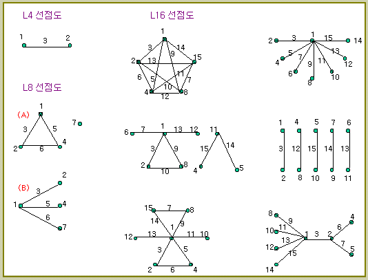

#### 직교배열표의 랜덤화

1. 요인들을 직교배열표의 열에 배치한 후, 각 열에 배치된 요인의 2수준을 랜덤하게 0, 1에 할당
2. $2^n$번의 실험을 완전히 랜덤한 순서대로 실시

#### 플라스틱 제품 신도 예시

- 온도 A, 습도 B, 압력 C, 진동 D

```r
library(tidyverse)
library(tidymodels)
```

```r
elastic <- c(13, 10, 19, 9, 14, 10 ,18 ,17)
temp <- c(0, 0, 0, 0, 1, 1, 1, 1) %>% factor
humid <- c(0, 0, 1, 1, 0, 0, 1, 1) %>% factor
press <- c(0, 1, 0, 1, 0, 1, 0, 1) %>% factor
vib <- c(0, 1, 1, 0, 1, 0 ,0, 1) %>% factor
dat = tibble(elastic, temp, humid, press, vib)
```

- 요인 A와 D의 효과가 유의하지 않음

```r
model1 <- aov(elastic ~ temp + humid + press + vib, dat)
tidy(model1)
```

A tibble: 5 × 6

| term <chr> | df <dbl> | sumsq <dbl> | meansq <dbl> | statistic <dbl> | p.value <dbl> |
| --- | --- | --- | --- | --- | --- |
| temp | 1 | 8.0 | 8.000000 | 1.655172 | 0.28854783 |
| humid | 1 | 32.0 | 32.000000 | 6.620690 | 0.08227332 |
| press | 1 | 40.5 | 40.500000 | 8.379310 | 0.06277211 |
| vib | 1 | 12.5 | 12.500000 | 2.586207 | 0.20616472 |
| Residuals | 3 | 14.5 | 4.833333 | NA | NA |

- 유의하지 않은 변수들을 제거한 후 재분석
  - 요인 B와 C가 신도에 영향을 미칠 것으로 기대

```r
model2 <- aov(elastic ~ humid + press + vib, dat)
tidy(model2)
```

A tibble: 4 × 6

| term <chr> | df <dbl> | sumsq <dbl> | meansq <dbl> | statistic <dbl> | p.value <dbl> |
| --- | --- | --- | --- | --- | --- |
| humid | 1 | 32.0 | 32.000 | 5.688889 | 0.07556582 |
| press | 1 | 40.5 | 40.500 | 7.200000 | 0.05504061 |
| vib | 1 | 12.5 | 12.500 | 2.222222 | 0.21029538 |
| Residuals | 4 | 22.5 | 5.625 | NA | NA |

- 최적조합에서의 모평균 추정치 = 14 + 4 = 18

```r
lmmod <- lm(elastic ~ humid + press, dat)
tidy(lmmod)
```

A tibble: 3 × 5

| term <chr> | estimate <dbl> | std.error <dbl> | statistic <dbl> | p.value <dbl> |
| --- | --- | --- | --- | --- |
| (Intercept) | 14.0 | 1.620185 | 8.640988 | 0.0003428494 |
| humid1 | 4.0 | 1.870829 | 2.138090 | 0.0855238045 |
| press1 | -4.5 | 1.870829 | -2.405351 | 0.0612145983 |

## 09.04. 다구치 품질공학

- **품질 : 제품이 출하된 시점으로부터, 성능특성값의 변동과 부작용으로 인하여 사용에 끼친 손실**

#### 설계단계

1. **제품의 성능특성값에 변동에 가장 큰 영향을 미치는 단계를 제품의 설계단게 (제품설계 및 공정설계) $\rightarrow$ QC필요**

#### 손실함수

- **제품특성의 목표치가 $m$이고, 제품의 실제 특성값이 $y$인경우, 손실함수**

  $$L(y) = k(y-m)^2$$

  특성값 $y$가 목표치 $m$에서 멀어질수록 그에 따른 손실은 더욱더 증가 ($k$는 상수)

  좋은 품질의 제품은 손실함수의 값을 작게 하는 것

#### 잡음의 사용

- 제품성능의 변동에 영향을 미치는 것은 '제어가능한 변수'와 '제어 불가능한 잡음'으로 분류
1. 외부잡음 : 외부 사용환경조건의 변화에 의한 잡음
2. 내부잡음 : 사용하면서 발생하는 내부 마모나 열화에 의한 잡음
3. 제품 간 잡음 : 제품의 불완전제조에 의하여 발생되는 제품간 성능특성의 산포로 인한 잡음

#### 라인 외 품질관리와 라인 내 품질관리의 구분

- 라인 내 품질관리 (online QC) : 생산라인에서의 품질관리 활동

#### 잡음제거의 기능

- 잡음제거의 대부분은 설게$\bullet$개발의 연구단계와 생산기술의 공정설계단계에서 이루어져야 함

```
잡음제거방법 가능 여부
```

| 품질관리 구분 | 담당부서 | 대응책 | 외부잡음 | 내부잡음 | 제품 간 잡음 |
| --- | --- | --- | --- | --- | --- |
| 라인 외 품질관리 | 설계& 개발 (research and development) | 1. 시스템설계 2. 파라미터 설계 3. 허용차 설계 | 대응가능 대응가능 대응가능 하나 최후의 수단 | 대응가능 대응가능 대응가능 | 대응가능 대응가능 대응가능 |
|  | 생산기술 (production engineering) | 1. 시스템 설계 2. 파라미터 설계 3. 허용차 설계 | 대응 불가능 대응 불가능 대응 불가능 | 대응 블가능 대응 불가능 대응 불가능 | 대응가능 대응가능 대응가능 |
| 라인 내 품질관리 | 생산 (production) | 1. 공정진단과 조정 2. 예측과 수정 3. 검사(측정과 조치) | 대응 불가능 대응 불가능 대응 불가능 | 대응 블가능 대응 불가능 대응 불가능 | 대응가능 대응가능 대응가능 |
|  | 판매 (sales) | A/S | 대응 불가능 | 예방보전의 의미로서 가능 | 예방보전의 의미로서 가능 |

#### 품질향상계획에서의 주안점

1. 목표치에 대한 성능특성값의 변동을 끊임없이 감소
2. 제품의 공정을 설계하거나 개선할 때, 제품의 성능특성값이 잡음에 둔감(robust)하도록 하여야 함
3. 제품이나 공정을 설계할 때는 적은 비용이 소요되면서, 목표치의 허용한계를 만족시키는 설계변수들의 최적조건을 탐색
4. 1.을 만족시키기 위해서 SN비를 특성값으로 사용하여, 변동을 최소화

   2.와 3.을 만족시키기 위해 직교배열표를 사용

### 제품설계의 3단계

1. 시스템 설계
- 제품의 원형 개발
- 두 세가지의 가능성 있는 설계를 한 후, 다음 단계에서 보완
1. 파라미터 설계
- 파라미터 : 제품성능의 특성값에 영향을 미치는 제어가능한 인자를 의미 (설게변수, design variable)
  - (공학에서의 파라미터는 통계의 그 것과 의미가 다름)

    즉 파라미터 설계는인자의 최적수준을 정하는 것
- 목표품질을 만족시키는 범위 내에서 가능하면 비용이 적게 드는 조건이나 부품을 사용
  - 잡음을 포함시켜 최적설계하는 직교배열표를 사용
1. 허용차 설계
- 최적조건을 구하였으나, 품질특성값의 변동이 만족할 만한 상태가 아닌 경우에 수행
- 사용환경의 변화에 따르는 영향을 조사하여, 큰 영향을 미치는 원인을 탐색

  허용차를 줄일 수 있도록 부품을 선별적으로 교체하는 등의 작업방법에 대한 조치
- 변동을 줄이기 위해서는 비용이 증가하므로, 만족스러운 허용차를 얻는 범위 내에서 최소비용이 드는 방법 고려 (직교배열표 사용)

## 09.06. 품질정보의 해석 (손실함수, SN비)

### 손실함수

- **망목특성 : 특정 목표치 ($m$)가 있는 특성으로, 손실함수는**

  $$L(y) = k(y-m)^2$$

  **소비자 허용한계점 $m\pm \Delta$에서 소비자의 손실이 $A$면, $k=\frac{A}{\Delta^2}$**

  **기대손실은$$L=k[\sigma^2+(\mu-m)^2]$$**
- **망소특성 : 특성값이 작을수록 좋은 것, $m=0$**

  **손실함수는 $$L(y)=ky^2,\;\;\;k=A/\Delta^2$$이고, 기대손실은$$L=kE(y^2)=kE[(y-\mu)+\mu]^2=k(\sigma^2+\mu^2)$$**
- **망대특성 : 특성값이 클수록 좋은 것, $m=0$**

  **손실함수는 $$L(y)=k({1\over{y^2}})^2,\;\;\;k=A\Delta^2$$이고, 기대손실은$$L=k({1\over{\mu}})^2(1+\frac{3\sigma^2}{\mu^2})$$**

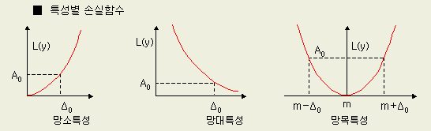

### SN비 (signal-to-noise ratio)

- **SN비는 신호대 잡음의 비율**

  $$SN = \frac{목적이\;산출물의\;결과에\;어느\;정도\;반영되는가?}{잡음의\;크기가\;산출물의\;결과에\;어느\;정도\;나쁜\;영향을\;미치는가?}=\frac{신호입력이\;산출물에\;전달된\;힘}{잡음이\;산출물에\;전달된\;힘}$$

  $$=\frac{신호의\;힘(power\;of\;signal)}{잡음의\;힘(power\;of\;noise)}(=\frac{\mu^2}{\sigma^2})$$

### 망목특성인 경우

- 만약 n개의 데이터 $y_1, \dots y_n$이 얻어졌다면, $\sigma^2$의 추정치

  $$\hat{\sigma^2}=V=\sum^n_i(y_i-\bar{y})^2/(n-1)$$이 되고, $\mu^2$의 추정치는 $S=(y_1 + \dots+y_n)^2/n$으로 놓는 경우

  $E(S_n)=\sigma^2+n\mu^2$로부터 $\hat{\mu}^2=\frac{1}{n}(S_n-V)$이므로

  $$SN비 = \frac{\frac{1}{n}(S_n -V)}{V}$$를 얻음

  #### 실제 사용되는 SN비는 로그를 취하고 10을 곱하여 데시벨 단위로 표현

  $$SN비 = 10log[\frac{\frac{1}{n}(S_n -V)}{V}]$$ $S_n=n(\bar{y})^2$이므로,

  $$SN비 = 10log[\frac{(\bar{y})^2 -\frac{V}{n}}{V}]$$이며, $n$이 충분히 크다면 [$\bar{y}^2 >>> \frac{V}{n}$], $\frac{V}{n}$가 무시될 수 있을정도로 작아지므로, 표본분산 $V=s^2$($s$는 표본표준편차)로 나타내는 경우에

  $$SN비 = 10log[\frac{(\bar{y})^2}{V}]=10log[\frac{(\bar{y})^2}{s^2}]=20log[\frac{(\bar{y})^2}{s}]$$

  **이 값은 크면 클수록 신호의 힘이 크고, 잡믐의 힘이 작아지는 것으로, SN값이 가장 크게 하는 조건이 곧 최적 조건**

### 망소특성인 경우

$$SN비 = -10log[\frac{1}{n}\sum^n_i {y^2}]$$

### 망대특성인 경우

$$SN비 = -10log[\frac{1}{n}\sum^n_i \frac{1}{y^2}]$$

## 09.07. 파라미터 설계

- 각종 잡음의 영향하에서도 최적의 상태가 될 수 있도록 제어 가능한 인자의 최적조건을 탐색

### 주요 착안점

- 산포의 감소
- 평균치가 목표에 근접하도록
- 비용의 최소화
- 재현성 확인

### 설계 방법

1. 망소특성 / 망태특성
- 제어인자 및 비제어인자(소음)의 조합으로 이루어진 실험 실시

  (제어인자를 내측에 배치, 비제어인자를 외측에 배치)
- 망소특성 또는 망대특성인 경우 해당 SN비 계산
- SN비에 대한 분산분석으로 SN비에 영향을 미치는 제어인자 도출
- 찾은 인자들의 최적수준 결정 (경제성, 작업성 고려)
- 최적수준 조합에서 재현성 확인
1. 망목특성
- 제어인자 및 비제어인자(소음)의 조합으로 이루어진 실험 실시
- 해당 SN비와 $S_n$의 계산
- SN비에 대한 분산분석으로 SN비에 영향을 미치는 제어인자 도출
  - 산포제어인자 : SN비에 유의한 영향을 미치는 인자
  - 평균조정인자 : $\bar{y}$에만 유의한 영향을 미치는 인자
  - 기타제어인자 : SN비나 $\bar{y}$에 유의한 영향을 미치지 못하는 인자

    (어떤 인자가 SN비와 $\bar{y}$에 동시에 영향을 준다면 산포제어인자로 분류)
- 찾은 인자들의 최적수준 결정 (경제성, 작업성 고려)
- 최적수준 조합에서 재현성 확인

### 전기회사 예시 (망소특성 파라미터 설계)

- 설계상 제어인자 5가지
- 상호작용을 무시한 주효과만 $L_8(2^7)$ 직교배열표 배치 (내측배열)
- 잡음을 주는 비제어인자로는 여러 요인이 존재하지만, 이를 묶어 $N_0, N_1$로 분류 (=잡음인자 N), 반복은 3회 실시 (외측배열)

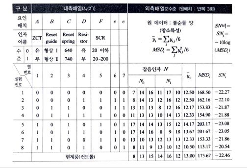

```r
sn <- c(-22.27, -22.1, -21.87, -21.88, -23.08, -23.05, -21.86, -20.54)
A <- c(0, 0, 0, 0, 1, 1, 1, 1) %>% factor
B <- c(0, 0, 1, 1, 0, 0, 1, 1) %>% factor
C <- c(0, 0, 1, 1, 1, 1, 0, 0) %>% factor
D <- c(0, 1, 0, 1, 0, 1, 0, 1) %>% factor
F <- c(0, 1, 0, 1, 1, 0, 1, 0) %>% factor
e1 <- c(0, 1, 1, 0, 0, 1, 1, 0) %>% factor
e2 <- c(0, 1, 1, 0, 1, 0, 0, 1) %>% factor

dat = tibble(sn, A, B, C, D, F, e1, e2)
```

- 변동이 작은 2개 인자 A, F를 풀링

```r
model1 <- aov(sn ~ A+B+C+D+F, dat)
tidy(model1)
```

A tibble: 6 × 6

| term <chr> | df <dbl> | sumsq <dbl> | meansq <dbl> | statistic <dbl> | p.value <dbl> |
| --- | --- | --- | --- | --- | --- |
| A | 1 | 0.0210125 | 0.0210125 | 0.09908635 | 0.78273400 |
| B | 1 | 2.3653125 | 2.3653125 | 11.15384615 | 0.07915625 |
| C | 1 | 1.2090125 | 1.2090125 | 5.70120837 | 0.13959283 |
| D | 1 | 0.2850125 | 0.2850125 | 1.34400236 | 0.36603289 |
| F | 1 | 0.1770125 | 0.1770125 | 0.83471854 | 0.45735593 |
| Residuals | 2 | 0.4241250 | 0.2120625 | NA | NA |

- B인자는 매우 유의하고, C인자 또한 유의, D인자는 유의하지 않음

```r
model2 <- aov(sn ~ B+C+D, dat)
tidy(model2)
```

A tibble: 4 × 6

| term <chr> | df <dbl> | sumsq <dbl> | meansq <dbl> | statistic <dbl> | p.value <dbl> |
| --- | --- | --- | --- | --- | --- |
| B | 1 | 2.3653125 | 2.3653125 | 15.207345 | 0.01754652 |
| C | 1 | 1.2090125 | 1.2090125 | 7.773125 | 0.04941122 |
| D | 1 | 0.2850125 | 0.2850125 | 1.832436 | 0.24727510 |
| Residuals | 4 | 0.6221500 | 0.1555375 | NA | NA |

```r
dat %>% group_by(B, C) %>% summarise(mean(sn))
```

A grouped_df: 4 × 3

| B <fct> | C <fct> | mean(sn) <dbl> |
| --- | --- | --- |
| 0 | 0 | -22.185 |
| 0 | 1 | -23.065 |
| 1 | 0 | -21.200 |
| 1 | 1 | -21.875 |